# RegressionModelProject

Nancy Pulido

2024-08-06

## Exploratory Data

#1. Exploratory Data Data mtcars

```r
#exploratory data
  head(mtcars)
```

```
##                    mpg cyl disp  hp drat    wt  qsec vs am gear carb
## Mazda RX4         21.0   6  160 110 3.90 2.620 16.46  0  1    4    4
## Mazda RX4 Wag     21.0   6  160 110 3.90 2.875 17.02  0  1    4    4
## Datsun 710        22.8   4  108  93 3.85 2.320 18.61  1  1    4    1
## Hornet 4 Drive    21.4   6  258 110 3.08 3.215 19.44  1  0    3    1
## Hornet Sportabout 18.7   8  360 175 3.15 3.440 17.02  0  0    3    2
## Valiant           18.1   6  225 105 2.76 3.460 20.22  1  0    3    1
```

```r
  str(mtcars)
```

```
## 'data.frame':    32 obs. of  11 variables:
##  $ mpg : num  21 21 22.8 21.4 18.7 18.1 14.3 24.4 22.8 19.2 ...
##  $ cyl : num  6 6 4 6 8 6 8 4 4 6 ...
##  $ disp: num  160 160 108 258 360 ...
##  $ hp  : num  110 110 93 110 175 105 245 62 95 123 ...
##  $ drat: num  3.9 3.9 3.85 3.08 3.15 2.76 3.21 3.69 3.92 3.92 ...
##  $ wt  : num  2.62 2.88 2.32 3.21 3.44 ...
##  $ qsec: num  16.5 17 18.6 19.4 17 ...
##  $ vs  : num  0 0 1 1 0 1 0 1 1 1 ...
##  $ am  : num  1 1 1 0 0 0 0 0 0 0 ...
##  $ gear: num  4 4 4 3 3 3 3 4 4 4 ...
##  $ carb: num  4 4 1 1 2 1 4 2 2 4 ...
```

```r
  summary(mtcars)
```

```
##       mpg             cyl             disp             hp
##  Min.   :10.40   Min.   :4.000   Min.   : 71.1   Min.   : 52.0
##  1st Qu.:15.43   1st Qu.:4.000   1st Qu.:120.8   1st Qu.: 96.5
##  Median :19.20   Median :6.000   Median :196.3   Median :123.0
##  Mean   :20.09   Mean   :6.188   Mean   :230.7   Mean   :146.7
##  3rd Qu.:22.80   3rd Qu.:8.000   3rd Qu.:326.0   3rd Qu.:180.0
##  Max.   :33.90   Max.   :8.000   Max.   :472.0   Max.   :335.0
##       drat             wt             qsec             vs
##  Min.   :2.760   Min.   :1.513   Min.   :14.50   Min.   :0.0000
##  1st Qu.:3.080   1st Qu.:2.581   1st Qu.:16.89   1st Qu.:0.0000
##  Median :3.695   Median :3.325   Median :17.71   Median :0.0000
##  Mean   :3.597   Mean   :3.217   Mean   :17.85   Mean   :0.4375
##  3rd Qu.:3.920   3rd Qu.:3.610   3rd Qu.:18.90   3rd Qu.:1.0000
##  Max.   :4.930   Max.   :5.424   Max.   :22.90   Max.   :1.0000
##        am              gear            carb
##  Min.   :0.0000   Min.   :3.000   Min.   :1.000
##  1st Qu.:0.0000   1st Qu.:3.000   1st Qu.:2.000
##  Median :0.0000   Median :4.000   Median :2.000
##  Mean   :0.4062   Mean   :3.688   Mean   :2.812
##  3rd Qu.:1.0000   3rd Qu.:4.000   3rd Qu.:4.000
##  Max.   :1.0000   Max.   :5.000   Max.   :8.000
```

```r
  describe(mtcars)
```

```
## mtcars
##
##  11  Variables      32  Observations
## --------------------------------------------------------------------------------
## mpg
##        n  missing distinct     Info     Mean      Gmd      .05      .10
##       32        0       25    0.999    20.09    6.796    12.00    14.34
##      .25      .50      .75      .90      .95
##    15.43    19.20    22.80    30.09    31.30
##
## lowest : 10.4 13.3 14.3 14.7 15  , highest: 26   27.3 30.4 32.4 33.9
## --------------------------------------------------------------------------------
## cyl
##        n  missing distinct     Info     Mean      Gmd
##       32        0        3    0.866    6.188    1.948
##
## Value          4     6     8
## Frequency     11     7    14
## Proportion 0.344 0.219 0.438
##
## For the frequency table, variable is rounded to the nearest 0
## --------------------------------------------------------------------------------
## disp
##        n  missing distinct     Info     Mean      Gmd      .05      .10
##       32        0       27    0.999    230.7    142.5    77.35    80.61
##      .25      .50      .75      .90      .95
##   120.83   196.30   326.00   396.00   449.00
##
## lowest : 71.1 75.7 78.7 79   95.1, highest: 360  400  440  460  472
## --------------------------------------------------------------------------------
## hp
##        n  missing distinct     Info     Mean      Gmd      .05      .10
##       32        0       22    0.997    146.7    77.04    63.65    66.00
##      .25      .50      .75      .90      .95
##    96.50   123.00   180.00   243.50   253.55
##
## lowest :  52  62  65  66  91, highest: 215 230 245 264 335
## --------------------------------------------------------------------------------
## drat
##        n  missing distinct     Info     Mean      Gmd      .05      .10
```

[output cut: 37 more lines]

```
## Frequency     15    12     5
## Proportion 0.469 0.375 0.156
##
## For the frequency table, variable is rounded to the nearest 0
## --------------------------------------------------------------------------------
## carb
##        n  missing distinct     Info     Mean      Gmd
##       32        0        6    0.929    2.812    1.718
##
## Value          1     2     3     4     6     8
## Frequency      7    10     3    10     1     1
## Proportion 0.219 0.312 0.094 0.312 0.031 0.031
##
## For the frequency table, variable is rounded to the nearest 0
## --------------------------------------------------------------------------------
```

## Exploratory Plots

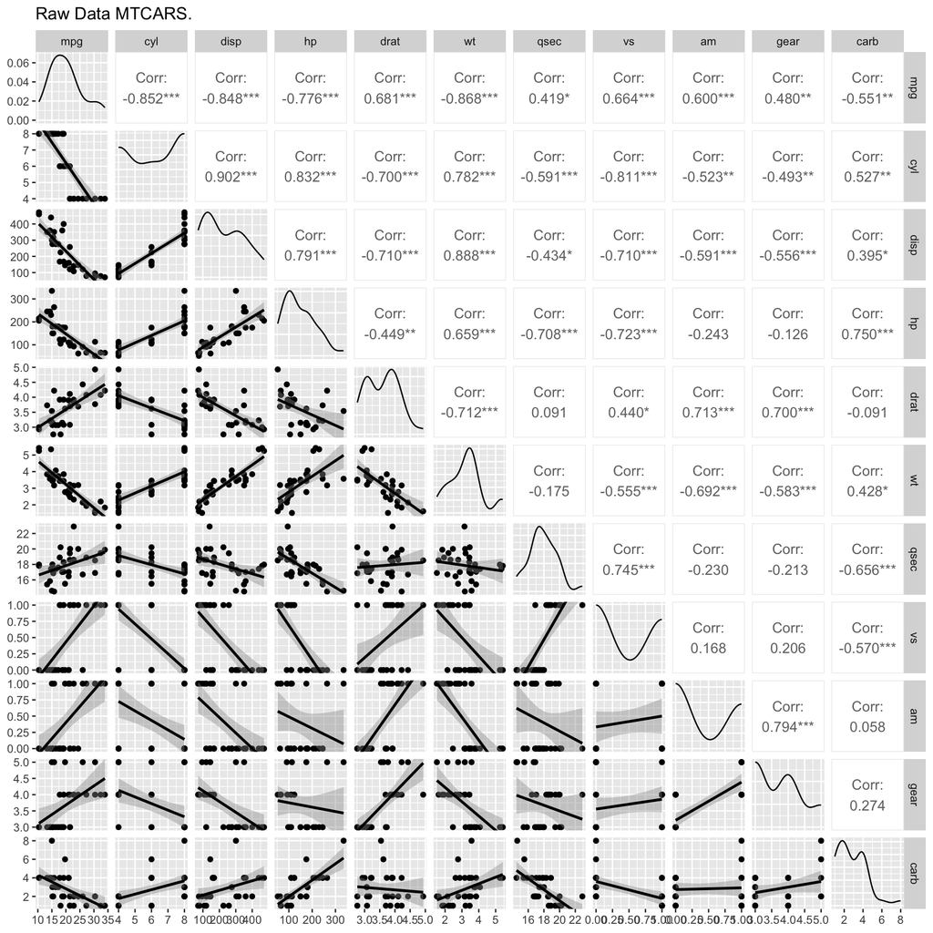

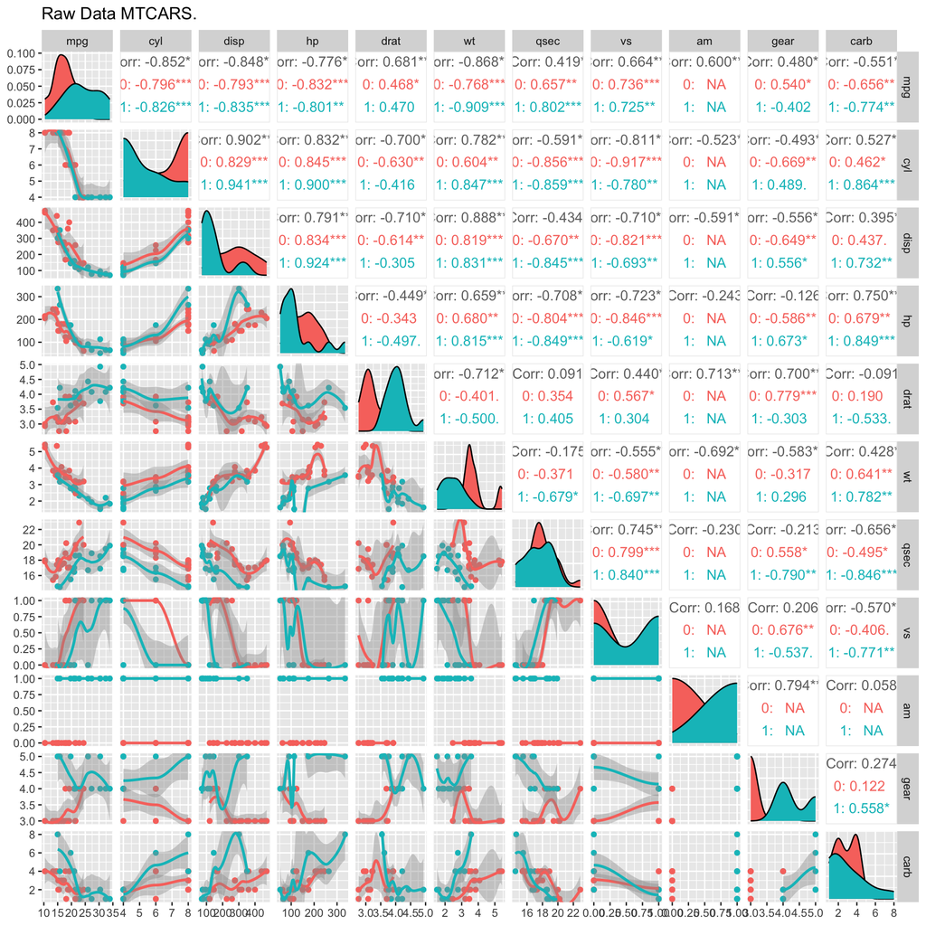

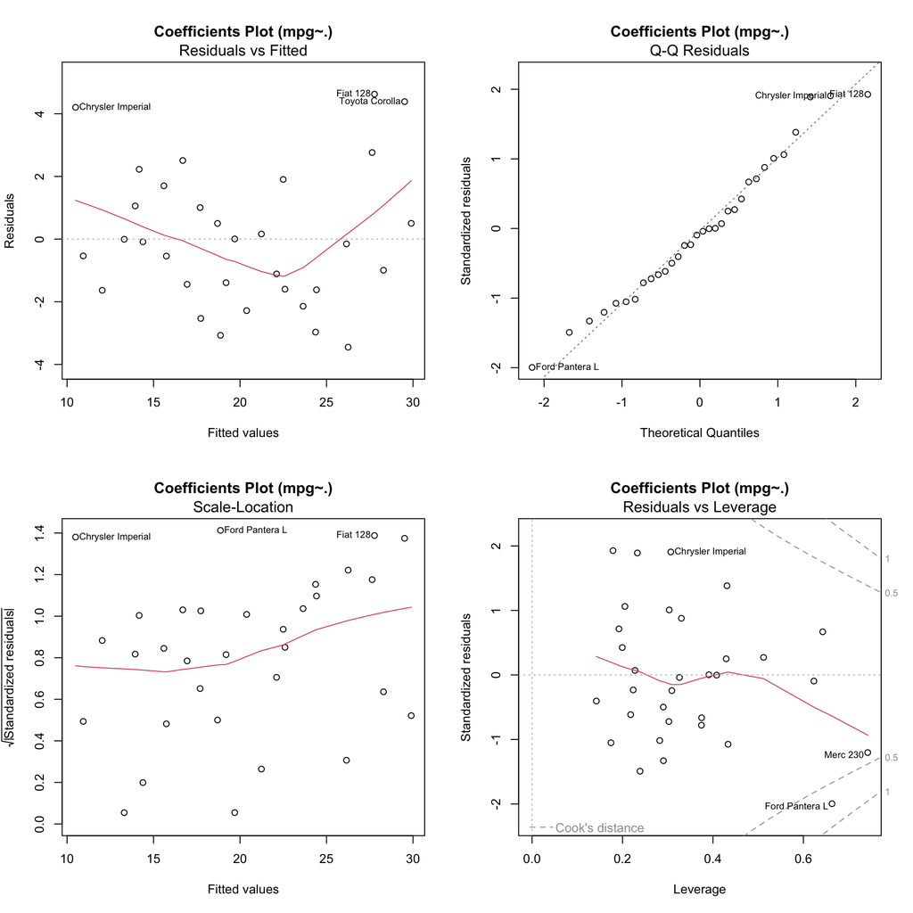

#Part 2: Exploratory Models

#General Model model:mpg~cyl

Coefficients for model: mpg~cyl

|  | Estimate | Std. Error | t value | Pr(>\|t\|) |
| --- | --- | --- | --- | --- |
| (Intercept) | 37.88458 | 2.0738436 | 18.267808 | 0 |
| cyl | -2.87579 | 0.3224089 | -8.919699 | 0 |

Analysis of Variance Table Model: mpg~cyl

| Res.Df | RSS | Df | Sum of Sq | F | Pr(>F) |
| --- | --- | --- | --- | --- | --- |
| 21 | 147.4944 | NA | NA | NA | NA |
| 30 | 308.3342 | -9 | -160.8398 | 2.544455 | 0.037424 |

#3.Comparing Models: Models - loop - explain function

Models summary - loop print out

Models Table

| Model | Adj_R_Squared | AIC | BIC | SignificatPredictors |
| --- | --- | --- | --- | --- |
| mpg~cyl | 0.7170527 | 169.3064 | 173.7036 | 1 |
| mpg~disp | 0.7089548 | 170.2094 | 174.6066 | 1 |
| mpg~ cyl+disp | 0.7429841 | 167.1456 | 173.0086 | 2 |
| mpg~hp | 0.5891853 | 181.2386 | 185.6358 | 1 |
| mpg~ cyl+disp + hp | 0.7430186 | 168.0184 | 175.3471 | 1 |
| mpg~drat | 0.4461283 | 190.7999 | 195.1971 | 1 |
| mpg~ cyl+disp + hp + drat | 0.7502914 | 167.9360 | 176.7304 | 1 |
| mpg~wt | 0.7445939 | 166.0294 | 170.4266 | 1 |
| mpg~ cyl+disp + hp + drat + wt | 0.8227219 | 157.7659 | 168.0260 | 2 |
| mpg~qsec | 0.1478062 | 204.5881 | 208.9853 | 1 |
| mpg~ cyl+disp + hp + drat + wt + qsec | 0.8199798 | 159.0020 | 170.7279 | 1 |
| mpg~vs | 0.4223126 | 192.1471 | 196.5443 | 1 |
| mpg~ cyl+disp + hp + drat + wt + qsec + vs | 0.8126278 | 160.9766 | 174.1682 | 1 |
| mpg~am | 0.3384589 | 196.4844 | 200.8816 | 1 |
| mpg~ cyl+disp + hp + drat + wt + qsec + vs + am | 0.8218062 | 160.0075 | 174.6648 | 1 |
| mpg~gear | 0.2050292 | 202.3638 | 206.7611 | 1 |
| mpg~ cyl+disp + hp + drat + wt + qsec + vs + am + gear | 0.8149224 | 161.7979 | 177.9210 | 1 |

# 4 & 5. Model Diagnostics and models validation

based on the best adjusted R squared models from loop

```
## [1] 0.8227219
```

#Analysis 1 - VIF values help to identify multicollinearity among predictors. Values above 10 indicate problematic multicollinearity. - RMSE is a measure of how well the model’s predictions match the actual values. Lower RMSE indicates better model performance.

Residual Plots: Diagnostic plots help to check the assumptions of linear regression, including linearity, homoscedasticity, and normality of residuals.

Models with highest Adjusted R squared anova - explain what it does

```r
#anova
  anova(modelF1,modelF2,modelF3,modelF4)
```

```
## Analysis of Variance Table
##
## Model 1: mpg ~ cyl + disp + hp + drat + wt
## Model 2: mpg ~ cyl + disp + hp + drat + wt + qsec
## Model 3: mpg ~ cyl + disp + hp + drat + wt + qsec + vs + am
## Model 4: mpg ~ cyl + disp + hp + drat + wt + qsec + vs + am + gear
##   Res.Df    RSS Df Sum of Sq      F Pr(>F)
## 1     26 167.43
## 2     25 163.48  1    3.9493 0.5875 0.4516
## 3     23 148.87  2   14.6040 1.0862 0.3549
## 4     22 147.90  1    0.9717 0.1445 0.7075
```

```r
  c(modelF1VIF, modelF2VIF,modelF3VIF,modelF4VIF)
```

```
##       cyl      disp        hp      drat        wt       cyl      disp        hp
##  7.869010 10.463957  3.990380  2.662298  5.168795  9.958978 10.550573  5.357783
##      drat        wt      qsec       cyl      disp        hp      drat        wt
##  2.966519  7.181690  4.039701 13.347224 10.646573  5.931238  3.122224  7.599975
##      qsec        vs        am       cyl      disp        hp      drat        wt
##  6.635692  4.923095  4.162232 14.573542 11.783934  7.105430  3.230897  7.838669
##      qsec        vs        am      gear
##  6.984654  4.923203  4.630597  4.392711
```

```r
  c(modelF1RMSE,modelF2RMSE,modelF3RMSE,modelF4RMSE)
```

```
## [1] 2.287371 2.260232 2.156913 2.149863
```

#6 corrections to Model Diagnostics - removing cyl and displasment - comparison with first set - choose best models based on adjusted R2

```
## [1] 0.8227219
```

print new diagnostics (remove cyl and disp) - anova model results: - vif results shoes cyl and disp values implies multilinearity. - rim results:

```r
#anova
  anova(model2F_1,model2F_2,model2F_3,model2F_4)
```

```
## Analysis of Variance Table
##
## Model 1: mpg ~ hp + drat + wt
## Model 2: mpg ~ hp + drat + wt + qsec
## Model 3: mpg ~ hp + drat + wt + qsec + vs + am
## Model 4: mpg ~ hp + drat + wt + qsec + vs + am + gear
##   Res.Df    RSS Df Sum of Sq      F Pr(>F)
## 1     28 183.68
## 2     27 174.10  1    9.5784 1.4499 0.2403
## 3     25 158.56  2   15.5448 1.1765 0.3255
## 4     24 158.56  1    0.0035 0.0005 0.9819
```

```r
  c(model2F_1VIF, model2F_2VIF,model2F_3VIF,model2F_4VIF)
```

```
##       hp     drat       wt       hp     drat       wt     qsec       hp
## 1.769308 2.033837 2.869445 4.921958 2.035473 3.582683 2.876115 5.070665
##     drat       wt     qsec       vs       am       hp     drat       wt
## 2.709905 5.105979 5.776361 4.120656 3.272177 5.364885 3.028679 5.135893
##     qsec       vs       am     gear
## 5.794930 4.253778 4.257110 3.452507
```

```r
  c(model2F_1RMSE,model2F_2RMSE,model2F_3RMSE,model2F_4RMSE)
```

```
## [1] 2.395842 2.332538 2.225974 2.225949
```

discuss the new anova results - while the results are more signficant than the previous set, there is not signigficat results. However, the models suggest the presence of the power equation p=force*velocity where power is expressed in hp.

#New Model explain power equation model

```r
proposedLM1<-lm(mpg~(qsec+hp), data=mtcars)
proposedLM2<-lm(mpg~hp,data=mtcars)
```

#diagnostic to new model

```r
anova(model2F_1,model2F_2,model2F_3,model2F_4,proposedLM1,proposedLM2)
```

```
## Analysis of Variance Table
##
## Model 1: mpg ~ hp + drat + wt
## Model 2: mpg ~ hp + drat + wt + qsec
## Model 3: mpg ~ hp + drat + wt + qsec + vs + am
## Model 4: mpg ~ hp + drat + wt + qsec + vs + am + gear
## Model 5: mpg ~ (qsec + hp)
## Model 6: mpg ~ hp
##   Res.Df    RSS Df Sum of Sq      F    Pr(>F)
## 1     28 183.68
## 2     27 174.10  1     9.578 1.4499 0.2402931
## 3     25 158.56  2    15.545 1.1765 0.3255231
## 4     24 158.56  1     0.003 0.0005 0.9818604
## 5     29 408.89 -5  -250.339 7.5786 0.0002158 ***
## 6     30 447.67 -1   -38.781 5.8701 0.0233129 *
## ---
## Signif. codes:  0 '***' 0.001 '**' 0.01 '*' 0.05 '.' 0.1 ' ' 1
```

#response to project question 1

```
##
## Call:
## lm(formula = mpg ~ (hp + qsec), data = manualTransmision)
##
## Coefficients:
## (Intercept)           hp         qsec
##     2.18940     -0.03141      1.50849
```

```
##
## Call:
## lm(formula = mpg ~ (hp + qsec), data = automaticTransmition)
##
## Coefficients:
## (Intercept)           hp         qsec
##    28.21035     -0.06099     -0.07088
```

```
##
## Call:
## lm(formula = mpg ~ (hp + qsec), data = manualTransmision)
##
## Residuals:
##     Min      1Q  Median      3Q     Max
## -5.4234 -2.5638  0.0303  1.9067  6.2667
##
## Coefficients:
##             Estimate Std. Error t value Pr(>|t|)
## (Intercept)  2.18940   22.48164   0.097    0.924
## hp          -0.03141    0.02430  -1.293    0.225
## qsec         1.50849    1.13946   1.324    0.215
##
## Residual standard error: 3.733 on 10 degrees of freedom
## Multiple R-squared:  0.6946, Adjusted R-squared:  0.6335
## F-statistic: 11.37 on 2 and 10 DF,  p-value: 0.002657
```

```
##
## Call:
## lm(formula = mpg ~ (hp + qsec), data = automaticTransmition)
##
## Residuals:
##     Min      1Q  Median      3Q     Max
## -4.0333 -1.9213  0.6238  1.5701  2.8711
##
## Coefficients:
##             Estimate Std. Error t value Pr(>|t|)
## (Intercept) 28.21035   11.55181   2.442  0.02659 *
## hp          -0.06099    0.01660  -3.674  0.00205 **
## qsec        -0.07088    0.51102  -0.139  0.89142
## ---
## Signif. codes:  0 '***' 0.001 '**' 0.01 '*' 0.05 '.' 0.1 ' ' 1
##
## Residual standard error: 2.258 on 16 degrees of freedom
## Multiple R-squared:  0.6918, Adjusted R-squared:  0.6532
## F-statistic: 17.95 on 2 and 16 DF,  p-value: 8.146e-05
```

interpretation:

Residuals: The distribution of residuals (differences between observed and predicted mpg values) indicates the variability in the model’s predictions. The min, 1Q, median, 3Q, and max values provide a summary of this distribution. Coefficients: Intercept (2.18940): This is the estimated mpg when both horsepower (hp) and quarter-mile time (qsec) are zero. While this isn’t practically interpretable, it serves as the baseline value. hp (-0.03141): The negative coefficient suggests that an increase in horsepower is associated with a decrease in mpg. However, this relationship is not statistically significant (p-value = 0.225). qsec (1.50849): The positive coefficient suggests that an increase in the quarter-mile time is associated with an increase in mpg, but this relationship is also not statistically significant (p-value = 0.215).

Model Significance: Residual standard error (3.733): This indicates the average distance that the observed values fall from the regression line. Multiple R-squared (0.6946): This indicates that approximately 69.46% of the variability in mpg is explained by the model. Adjusted R-squared (0.6335): This adjusts the R-squared value for the number of predictors in the model. F-statistic (11.37) and p-value (0.002657): The F-statistic tests whether at least one of the predictors is statistically significant. The low p-value indicates that the model is statistically significant overall. Automatic Transmission Model Interpretation:

Residuals: The residuals show the variability in the model’s predictions for automatic transmissions. Coefficients: Intercept (28.21035): This represents the estimated mpg when both horsepower and quarter-mile time are zero. hp (-0.06099): The negative coefficient indicates that an increase in horsepower is associated with a decrease in mpg, and this relationship is statistically significant (p-value = 0.00205). qsec (-0.07088): The coefficient suggests a slight decrease in mpg with an increase in quarter-mile time, but this relationship is not statistically significant (p-value = 0.89142). Model Significance: Residual standard error (2.258): Indicates the average distance that the observed values fall from the regression line. Multiple R-squared (0.6918): Indicates that approximately 69.18% of the variability in mpg is explained by the model. Adjusted R-squared (0.6532): Adjusts the R-squared value for the number of predictors in the model. F-statistic (17.95) and p-value (8.146e-05): The low p-value indicates that the model is statistically significant overall. Comparison and Conclusion Both models have similar R-squared values, indicating that they explain a similar proportion of the variability in mpg. The model for automatic transmissions has a statistically significant coefficient for horsepower, indicating a reliable negative relationship between horsepower and mpg. The model for manual transmissions does not have statistically significant coefficients for either predictor. The overall model significance (F-statistic and p-value) is strong for both models, but slightly stronger for the automatic transmission model. Based on this analysis, the relationship between horsepower, quarter-mile time, and mpg is more pronounced and statistically significant in automatic cars compared to manual cars in the mtcars dataset.